# Project 1 - Peer Review Draft

Over the past years anxiety has become a prevalent concern across all age groups. Many of the factors that contribute to anxiety attacks are diverse but certain lifestyle choices such as caffeine intake are increasingly being blamed. This research aims to explore the following question:

> Is There a Relationship Between Caffeine Intake, Alcohol Consumption, and Physical Activity to the Severity of Anxiety Attacks Among Different Age Groups (Young Adults, Adults, and Seniors)?

“Anxiety Attack Factors Symptoms and Severity” is the Kaggle dataset I selected for this project. This dataset has 12,000 rows with many factors related to anxiety attacks. Designed to explore patterns, triggers, and potential correlations in anxiety disorders. In total, this dataset has a total of 20 factors including lifestyle habits, stress levels, major life events, caffeine intake, and heart rate.

Link to the Dataset: [Anxiety Attack Factors](https://www.kaggle.com/datasets/ashaychoudhary/anxiety-attack-factors-symptoms-and-severity)

To explore this question, the following attributes will be needed:

- Age
- Caffeine Intake (mg/day)
- Alcohol Consumption (drinks/week)
- Physical Activity (hrs/week)
- Severity of Anxiety Attack (1-10)

To begin, will will import our data from the downloaded .csv file and import necessary libraries.

```python
import pandas as pd
import matplotlib.pyplot as plt

anxiety_df = pd.read_csv("anxiety_attack_dataset.csv")
```

To get a better understanding of what we are working with, lets run the following command:

- shape -- This gives us information on the number of columns and rows

```python
anxiety_df.shape
```

```
(12000, 20)
```

## Pre-Processing The Data

When pre-processing the data, I followed the OSEMN pipeline, which stands for Obtaining, Scrubbing, Exploring, Modeling, and Interpreting. One of the most critical and time-consuming steps is Scrubbing or cleaning the data. This step involves examining the data to identify errors, missing values, or corrupt records. In this case, no missing values were found, allowing us to proceed smoothly.

- We used .isna().sum() to identify any null values

```python
anxiety_df.isna().sum()
```

```
ID                                   0
Age                                  0
Gender                               0
Occupation                           0
Sleep Hours                          0
Physical Activity (hrs/week)         0
Caffeine Intake (mg/day)             0
Alcohol Consumption (drinks/week)    0
Smoking                              0
Family History of Anxiety            0
Stress Level (1-10)                  0
Heart Rate (bpm during attack)       0
Breathing Rate (breaths/min)         0
Sweating Level (1-5)                 0
Dizziness                            0
Medication                           0
Therapy Sessions (per month)         0
Recent Major Life Event              0
Diet Quality (1-10)                  0
Severity of Anxiety Attack (1-10)    0
dtype: int64
```

The next step is Exploring and visualizing the data, which helps us to uncover patterns and trends. I was able to extract features by using statistics to identify and test important variables.

```python
def categorizeAgeGroup(Age):
    if Age < 26:
        return "Young Adult"
    elif Age < 51:
        return "Adult"
    else:
        return "Senior"

anxiety_df['Age Group'] = anxiety_df['Age'].apply(categorizeAgeGroup)
```

```python
anxiety_df['Age Group'].value_counts()
```

```
Age Group
Adult          6489
Senior         3516
Young Adult    1995
Name: count, dtype: int64
```

```python
def categorizeCaffeineIntake(Intake):
    if Intake > 135:
        return "Above"
    else:
        return "Below"

anxiety_df['Over Avg Caffeine Intake']= anxiety_df['Caffeine Intake (mg/day)'].apply(categorizeCaffeineIntake)
```

## Data Understanding Through Visualization

To explore the relationship between caffeine intake, alcohol consumption, physical activity, and the severity of anxiety attacks among different age groups (Young Adults, Adults, and Seniors), I used a set of data visualization techniques like

- Bar Plot
- Facet Grid
- Histogram Plot
- Line Plot

Let's Begin!

To start, I created a bar plot to visualize the average severity of anxiety attacks across different age groups.

This visualization highlights that all age groups fall within the **5-6 range** on the average severity of anxiety attacks, with Seniors slightly lower and Young Adults slightly higher than Adults.

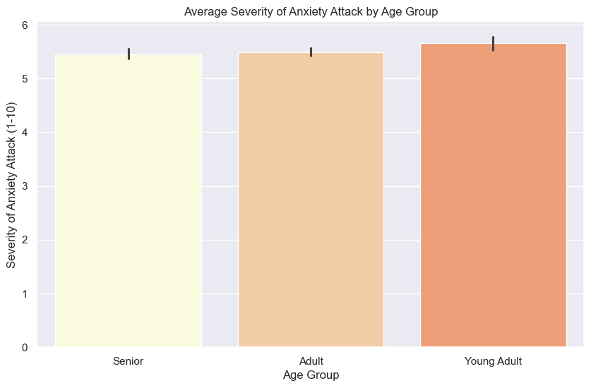

```python
plt.figure(figsize=(10, 6))
sns.barplot(x='Age Group', y='Severity of Anxiety Attack (1-10)', data=anxiety_df, palette=['#FDFFD9','#FFCC98','#FF9965'], hue='Age Group', legend=False)
plt.title('Average Severity of Anxiety Attack by Age Group')
plt.show()
```

This following bar plot highlights the average caffeine intake across different age groups. Here we can see that the Adult age group had the lowest average caffeine intake, slightly lower than the Senior group. While the Young Adult group exhibited the highest average caffeine intake.

Taking into account both visualizations, we can see a trend: the Young Adult group consistently showed the highest averages in both the severity of anxiety attacks and caffeine intake. This could suggest a potential link between higher caffeine consumption and increased anxiety severity among Young Adults.

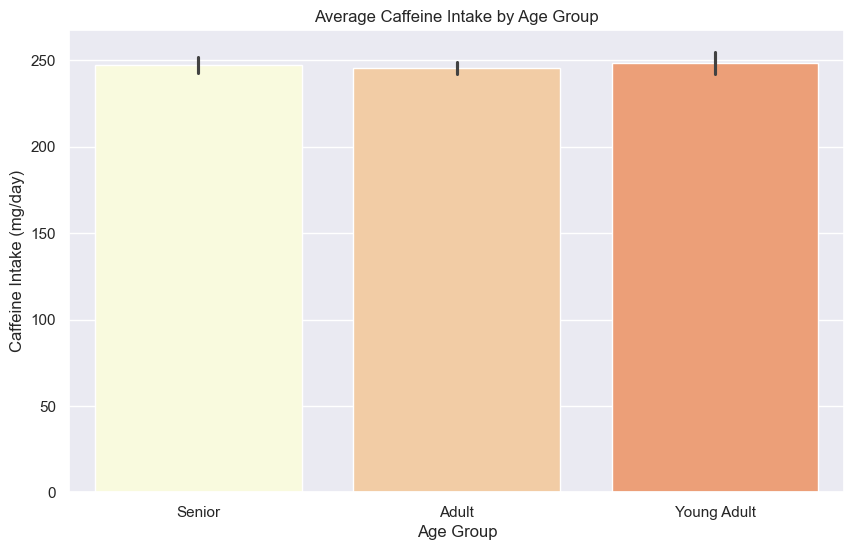

```python
plt.figure(figsize=(10, 6))
sns.barplot(x='Age Group', y='Caffeine Intake (mg/day)', data=anxiety_df, palette=['#FDFFD9','#FFCC98','#FF9965'], hue='Age Group', legend=False)
plt.title('Average Caffeine Intake by Age Group')
plt.show()
```

This following facet grid aims to break down the previous visualization by showing the number of individuals with above-average and below-average caffeine consumption within each age group. I observed that the Adult section had a much higher number of over-average caffeine intake compared to the Senior and Young Adult groups. The Senior group followed, with about 2500 individuals exceeding the US average caffeine intake of 135 mg/day.

Interestingly, the Young Adult section had the lowest numbers in this visualization. This finding might compromise my previous theory that higher caffeine consumption is linked to increased anxiety severity among Young Adults, since the Adults had a higher number of individuals consuming above-average caffeine but did not exhibit the highest anxiety severity.

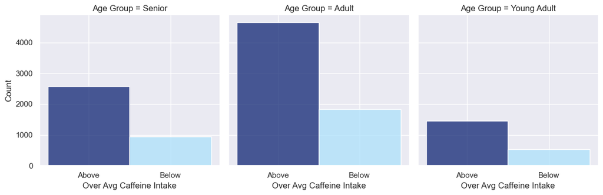

```python
g = sns.FacetGrid(anxiety_df, col="Age Group", col_wrap=3, height=4, hue="Over Avg Caffeine Intake", palette=["#0f2573", "#ade1fb"])
g.map(sns.histplot, "Over Avg Caffeine Intake")
plt.show()
```

This next visualization aims to bring together all the key variables we've been examining: severity of anxiety attacks, average caffeine intake, and age group.

The average severity of anxiety attacks for Young Adults is very similar regardless of whether their caffeine intake is above or below average. This would debunks our initial theory that higher caffeine consumption is linked to increased anxiety severity in Young Adults.

The plot also shows that Seniors with over average caffeine intake have a higher average severity of anxiety attacks compared to those with under average caffeine intake. This could indicate that Seniors may be more sensitive to caffeine, as previously observed in our data showing Seniors were in second place for the highest number of over caffeine consumers.

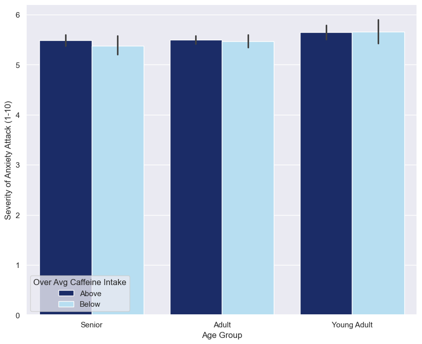

```python
plt.figure(figsize=(10,8))

sns.barplot(x='Age Group',y='Severity of Anxiety Attack (1-10)', data=anxiety_df,
            hue='Over Avg Caffeine Intake', palette=["#0f2573", "#ade1fb"])
plt.show()
```

The last visualization I had is just another point of view for our previous chart.

I noticed here that for Adults and Seniors, the severity of anxiety attacks decreases when caffeine intake goes below average. This could indicate that lower caffeine intake might be associated with reduced anxiety severity in these age groups.

In contrast, for Young Adults, there is a slight increase in the severity of anxiety attacks when their caffeine intake goes below average. This again contradicts our initial theory that higher caffeine consumption would lead to increased anxiety severity in Young Adults.

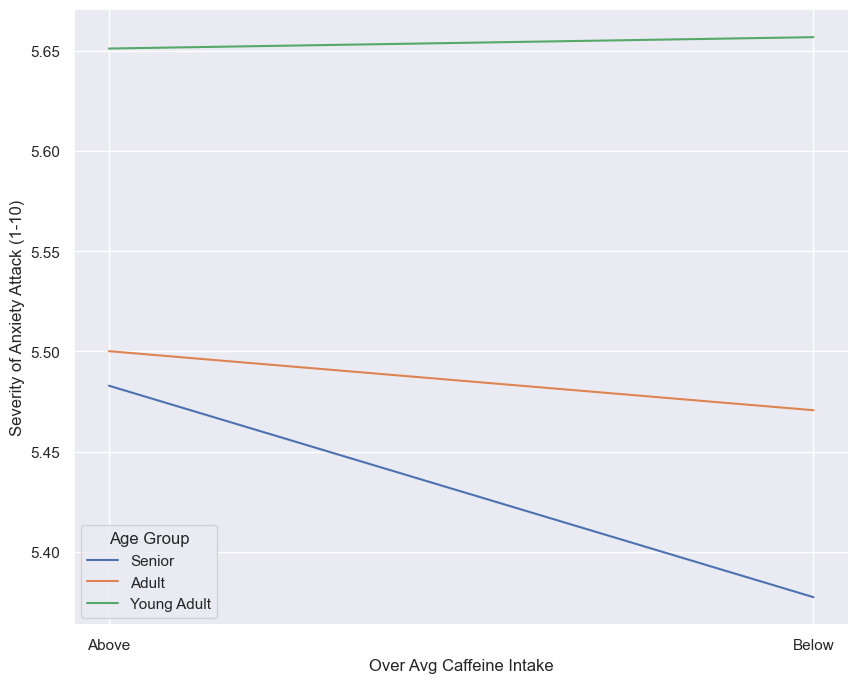

```python
plt.figure(figsize=(10,8))
sns.lineplot(data=anxiety_df, x='Over Avg Caffeine Intake', y='Severity of Anxiety Attack (1-10)', hue='Age Group', errorbar=None)
```

## Storytelling

Our initial bar plot revealed the average severity of anxiety attacks across different age groups. It was clear that all age groups fell within a similar range of 5-6 on a scale of 1 to 10, with Seniors slightly lower and Young Adults slightly higher in severity.

Next, we focused to caffeine intake. The bar plot used showed average caffeine intake by age group highlighted that Adults consumed the least caffeine, with Young Adults at the top and Seniors in the middle. From this visualization, I identified a trend of Young Adults consuming the most caffeine seemed consistent with their higher severity of anxiety attacks.

Diving deeper, I used a facet grid to break down caffeine consumption into over and under-average groups. This revealed a surprising insight: Adults had the highest number of individuals consuming over-average caffeine, followed by Seniors and then Young Adults. This finding tested my initial theory, suggesting that other factors might influence anxiety severity in Young Adults.

Finally, a line plot offered a fresh perspective on the relationship between these variables. I observed that for Adults and Seniors, the severity of anxiety attacks decreased with below-average caffeine intake, indicating a potential benefit of lower caffeine consumption. However, for Young Adults, the severity of anxiety attacks slightly increased with below-average caffeine intake, further complicating our initial assumptions.

I partially answered my inital question. I was able to identify relationships between caffeine intake and anxiety severity across different age groups. While the Young Adults group initially seemed to support my theory, further analysis showed that their anxiety severity didn't significantly differ with caffeine consumption levels. In contrast, for Seniors, higher caffeine intake correlated with increased anxiety severity, which could suggest a heightened sensitivity to caffeine in this age group.

## Impact

Analyzing these questions can help bring a better understanding of the relationship between factors and could aid healthcare providers in giving personalized recommendations. Such as how much caffeine consumption based on age can help manage anxiety symptoms better? Or help in building tailored treatment plans based on individual needs. However, there are still some possible risks like inaccurate conclusions due to individual differences in metabolism and other health conditions. Along with the risk of interpreting therapy or medication alone determines anxiety levels while disregarding other factors like a support system.

Missing data is also a big concern since we do not know the duration or type of physical activity as well as the source of caffeine which would be useful for an in depth analysis. For health issues, we do not have data on pre-existing heart conditions or exercise routine which can sway the conclusions in a way that does not apply to everyday patients.